# Modelos de Cox de Riesgos Proporcionales

# Introducción

En esta libreta de ejercicios prácticos, revisaremos los conceptos cubiertos en las sesión “Modelos de Cox de Riesgos Proporcionales”, incluyendo:

1. **Correr modelos de Cox de RP en R.**
2. **Evaluar los supuestos de los modelos.**

## Cargar los datos

Si reiniciaste tu sesión entre la práctica anterior y esta, tendrás que cargar los datos de nuevo, “limpiar” los nombres de las columnas, y generar de nuevo algunas de las columnas que usaremos.

```r
# Cargar el paquete data.table, instalado en el material previo al curso
pacman::p_load(data.table,janitor)

# Cargar los datos simulados 'MCPS-like.csv'
dummy_df <- data.table::fread(file = 'data/MCPS-like.csv')
dummy_df <- janitor::clean_names(dummy_df)

# Nombrar la nueva variable
dummy_df$new_diabetes <-
  # Devuelve un vector con el valor máximo de los vectores de entrada
  pmax(dummy_df$base_diabetes,
       dummy_df$drug_antidiabetic,
       # valores faltantes son removidos
       na.rm = TRUE)

# Hacer la nueva variable un factor
dummy_df$has_diabetes <-
  factor(dummy_df$new_diabetes,
         levels = c(0,1),
         labels = c("Sin diabetes", "Con diabetes"))

# Hacer una nueva variable de sexo como factor
dummy_df$sex <- factor(ifelse(dummy_df$male == 1, "Hombres", "Mujeres"))
```

# 1. Riesgos Proporcionales de Cox

Hasta ahora, hemos descrito la probabilidad de supervivencia con respecto a **un factor** (ej. sexo o diabetes). Sin embargo, sabemos que varios factores o covariables conocidos afectan la supervivencia (ej. edad, estatus socioeconómico, factores de estilo de vida como tabaquismo o consumo de alcohol).

Como se discutió en la clase, la regresión de Riesgos Proporcionales de Cox permite que la supervivencia sea evaluada con respecto a varios factores simultáneamente.

También ofrece estimaciones de la fuerza del efecto de cada factor.

## Diabetes y mortalidad por todas las causas

Estamos interesados en estimar la asociación entre diabetes al reclutamiento y mortalidad por todas las causas.

Para este análisis, ‘ajustaremos’ por los siguientes **factores confusores** incluyéndolos en el modelo de regresión:

- Edad
- Sexo
- Distrito de residencia
- Nivel educativo
- Tabaquismo, consumo de alcohol, y actividad física

Basándose en una gran cantidad de evidencia científica, es razonable asumir que los factores arriba pueden ser considerados factores confusores *conocidos*. Eso significa que estos factores están asociados (causalmente) con tanto la exposición (es decir, diabetes) como el desenlace (es decir, muerte).

Discutir el concepto de confusión en epidemiología está fuera del alcance de este práctico, pero [esta es una buena introducción](https://www.healthknowledge.org.uk/public-health-textbook/research-methods/1a-epidemiology/biases).

### Preparar covariables

Sigue los pasos abajo para preparar las covariables a ser incluidas en el modelo principal.

**Edad, sexo, y distrito de residencia**

```r
summary(dummy_df$age)
```

```
##    Min. 1st Qu.  Median    Mean 3rd Qu.    Max.
##   35.50   41.50   49.50   52.02   60.50   84.50
```

```r
summary(dummy_df$male)
```

```
##    Min. 1st Qu.  Median    Mean 3rd Qu.    Max.
##  0.0000  0.0000  0.0000  0.3235  1.0000  1.0000
```

```r
summary(dummy_df$coyoacan)
```

```
##    Min. 1st Qu.  Median    Mean 3rd Qu.    Max.
##  0.0000  0.0000  0.0000  0.3928  1.0000  1.0000
```

Para este análisis, modelaremos la edad (`age`) como una variable categórica (bandas de edad de 10 años).

```r
dummy_df$age_10yr <-
  cut(
    # Restar 0.5 para ajustar por truncamiento de edad
    dummy_df$age-0.5,
    # Puntos de corte que definen los límites de intervalos
    breaks = c(34, 44, 54, 64, 74, 84),
    # Etiquetas personalizadas para cada banda de edad
    labels = c("35-44", "45-54", "55-64", "65-74", "75-84"),
    # Intervalos cerrados por la derecha (excluye izq, incluye der)
    right = TRUE,
     # Incluir el punto de corte más bajo en el primer intervalo
    include.lowest = TRUE)

# Verificar que no se crearon NAs
table(dummy_df$age_10yr,useNA = "always")
```

```
##
## 35-44 45-54 55-64 65-74 75-84  <NA>
##  7184  5600  3682  2412  1122     0
```

Sexo (`male`) y distrito de residencia (`coyoacan`) mantendrán su código actual. No se necesitan más cambios para estas variables.

**Nivel educativo**

Para facilitar esta práctica, esta variable ya ha sido codificada en 4 niveles:  
1. Universidad  
2. Preparatoria  
3. Primaria y Secundaria  
4. Otro

Solo necesitamos decirle a R que trate esto como un `factor` para que entienda que es una variable categórica.

```r
summary(dummy_df$edu_level)
```

```
##    Min. 1st Qu.  Median    Mean 3rd Qu.    Max.
##   1.000   2.000   3.000   2.571   3.000   4.000
```

```r
table(dummy_df$edu_level)
```

```
##
##    1    2    3    4
## 3048 4987 9469 2496
```

```r
dummy_df$edu_level_cat <-
  factor(dummy_df$edu_level,
         levels = c(1, 2, 3, 4),
         labels = c("Universidad", "Preparatoria", "Primaria/Secundaria", "Otro"))

summary(dummy_df$edu_level_cat)
```

```
##         Universidad        Preparatoria Primaria/Secundaria                Otro
##                3048                4987                9469                2496
```

**Tabaquismo, consumo de alcohol, y actividad física**

Similar a lo anterior, necesitamos decirle a R que éstas son variables categóricas y agregar etiquetas.

```r
# Tabaquismo
summary(dummy_df$smokegp)
```

```
##    Min. 1st Qu.  Median    Mean 3rd Qu.    Max.
##   1.000   1.000   2.000   2.091   3.000   5.000
```

```r
table(dummy_df$smokegp)
```

```
##
##    1    2    3    4    5
## 9811 3900 2246 2744 1299
```

```r
dummy_df$smokegp_cat <-
  factor(dummy_df$smokegp,
         levels = c(1, 2, 3, 4, 5),
         labels = c("Nunca", "Ex-fumador", "<Diario", "Diario <10/día", "Diario 10+/día"))

summary(dummy_df$smokegp_cat)
```

```
##          Nunca     Ex-fumador        <Diario Diario <10/día Diario 10+/día
##           9811           3900           2246           2744           1299
```

```r
# Consumo de alcohol
summary(dummy_df$alcgp)
```

```
##    Min. 1st Qu.  Median    Mean 3rd Qu.    Max.
##   1.000   2.000   3.000   2.552   3.000   5.000
```

```r
table(dummy_df$alcgp)
```

```
##
##     1     2     3     4     5
##  3965  2673 12068   951   343
```

```r
dummy_df$alcgp_cat <-
  factor(dummy_df$alcgp,
         levels = c(1, 2, 3, 4, 5),
         labels = c("Nunca", "Ex-bebedor", "Hasta 3 veces/mes", "Hasta 2 veces/sem", "3+ veces/sem"))

summary(dummy_df$alcgp_cat)
```

```
##             Nunca        Ex-bebedor Hasta 3 veces/mes Hasta 2 veces/sem
##              3965              2673             12068               951
##      3+ veces/sem
##               343
```

```r
# Actividad física
summary(dummy_df$physgp)
```

```
##    Min. 1st Qu.  Median    Mean 3rd Qu.    Max.
##   1.000   1.000   1.000   1.369   1.000   3.000
```

```r
table(dummy_df$physgp)
```

```
##
##     1     2     3
## 15487  1656  2857
```

```r
dummy_df$physgp_cat <-
  factor(dummy_df$physgp,
         levels = c(1, 2, 3),
         labels = c("Ninguna", "Hasta 2 veces/sem", "3+ veces/sem"))

summary(dummy_df$physgp_cat)
```

```
##           Ninguna Hasta 2 veces/sem      3+ veces/sem
##             15487              1656              2857
```

### Correr un modelo de Cox univariado

Para empezar, podría ser útil explorar la asociación entre diabetes y mortalidad por todas las causas **sin** incluir factores de confusión.

```r
pacman::p_load(survival)
cox_mod_1 <-
  # Definir modelo usando la función coxph
  coxph(
    # El lado izquierdo de la ecuación incluye el seguimiento y la censura
    Surv(person_years,d000) ~
      # El lado derecho incluye todos los factores de interés
      has_diabetes,
      # Los datos a usar
      data = dummy_df)

# Usar summary para mostrar los resultados clave
summary(cox_mod_1)
```

```
## Call:
## coxph(formula = Surv(person_years, d000) ~ has_diabetes, data = dummy_df)
##
##   n= 20000, number of events= 3694
##
##                             coef exp(coef) se(coef)     z Pr(>|z|)
## has_diabetesCon diabetes 1.31754   3.73424  0.03591 36.69   <2e-16 ***
## ---
## Signif. codes:  0 '***' 0.001 '**' 0.01 '*' 0.05 '.' 0.1 ' ' 1
##
##                          exp(coef) exp(-coef) lower .95 upper .95
## has_diabetesCon diabetes     3.734     0.2678      3.48     4.007
##
## Concordance= 0.604  (se = 0.004 )
## Likelihood ratio test= 1091  on 1 df,   p=<2e-16
## Wald test            = 1346  on 1 df,   p=<2e-16
## Score (logrank) test = 1551  on 1 df,   p=<2e-16
```

Los resultados guardados en `cox_mod_1` muestran que los datos usados involucraron **20,000** participantes y **3,694** eventos.

Los coeficientes mostrados son el $log(HR)$. Para obtener el **hazard ratio**, necesitamos ‘exponenciar’ los coeficientes de regresión (es decir, $exp(log(HR))$).

En este ejemplo, el HR=3.73, con un intervalo de confianza del 95% que va de 3.48 a 4.00.

La manera usual de interpretar este coeficiente es que aquellos con diabetes tuvieron un riesgo de mortalidad por todas las causas casi cuatro veces mayor (HR 3.73, IC 95% 3.48-4.00) que aquellos sin diabetes al reclutamiento.

Puede ser útil ver el número de participantes y el número de eventos (es decir, muertes) que se observaron en cada uno de los niveles de tu factor de riesgo para asegurarte de que los números sí suman.

```r
# Número de participantes con vs sin diabetes
table(dummy_df$has_diabetes)
```

```
##
## Sin diabetes Con diabetes
##        17438         2562
```

```r
# Número de eventos (donde d000 == 1) para cada nivel de has_diabetes
table(dummy_df$has_diabetes, dummy_df$d000)
```

```
##
##                    0     1
##   Sin diabetes 14860  2578
##   Con diabetes  1446  1116
```

### Correr un modelo de Cox de múltiples variables

#### Instrucciones

Porque estamos interesados en la asociación entre diabetes y mortalidad por todas las causas mientras ajustamos por un conjunto de factores confusores, necesitamos agregar tales factores confusores al modelo de regresión.

```r
cox_mod_2 <-
  # Definir modelo usando la función coxph
  coxph(
    # El lado izquierdo de la ecuación incluye el seguimiento y la censura
    Surv(person_years,d000) ~
      # El lado derecho incluye todos los factores de interés
      has_diabetes + age_10yr + sex + coyoacan + edu_level_cat + smokegp_cat + alcgp_cat + physgp_cat,
      # Los datos a usar
      data = dummy_df)
```

Mira `summary(cox_mod_2)`. Trata de interpretar los resultados para la asociación de diabetes y mortalidad por todas las causas ajustada por factores de confusión.

#### Interpretación

```r
# Usar summary para mostrar los resultados clave
summary(cox_mod_2)
```

```
## Call:
## coxph(formula = Surv(person_years, d000) ~ has_diabetes + age_10yr +
##     sex + coyoacan + edu_level_cat + smokegp_cat + alcgp_cat +
##     physgp_cat, data = dummy_df)
##
##   n= 20000, number of events= 3694
##
##                                       coef exp(coef)  se(coef)       z Pr(>|z|)
## has_diabetesCon diabetes          0.884070  2.420733  0.036959  23.920  < 2e-16
## age_10yr45-54                     0.660479  1.935718  0.062307  10.600  < 2e-16
## age_10yr55-64                     1.278356  3.590732  0.062294  20.521  < 2e-16
## age_10yr65-74                     1.930293  6.891528  0.063046  30.617  < 2e-16
## age_10yr75-84                     2.392734 10.943375  0.069215  34.570  < 2e-16
## sexMujeres                       -0.445877  0.640263  0.040141 -11.108  < 2e-16
## coyoacan                         -0.368060  0.692076  0.036652 -10.042  < 2e-16
## edu_level_catPreparatoria         0.271465  1.311885  0.073907   3.673  0.00024
## edu_level_catPrimaria/Secundaria  0.370094  1.447870  0.068150   5.431 5.62e-08
## edu_level_catOtro                 0.314694  1.369840  0.077154   4.079 4.53e-05
## smokegp_catEx-fumador             0.028442  1.028851  0.045465   0.626  0.53158
## smokegp_cat<Diario                0.067642  1.069982  0.065239   1.037  0.29982
## smokegp_catDiario <10/día         0.038682  1.039439  0.057531   0.672  0.50136
## smokegp_catDiario 10+/día         0.353913  1.424631  0.068218   5.188 2.13e-07
## alcgp_catEx-bebedor               0.008364  1.008399  0.054364   0.154  0.87772
## alcgp_catHasta 3 veces/mes       -0.130928  0.877281  0.045016  -2.908  0.00363
## alcgp_catHasta 2 veces/sem       -0.056008  0.945531  0.089999  -0.622  0.53373
## alcgp_cat3+ veces/sem             0.188781  1.207777  0.108137   1.746  0.08085
## physgp_catHasta 2 veces/sem      -0.134769  0.873918  0.066744  -2.019  0.04347
## physgp_cat3+ veces/sem           -0.147883  0.862532  0.048919  -3.023  0.00250
##
## has_diabetesCon diabetes         ***
## age_10yr45-54                    ***
## age_10yr55-64                    ***
## age_10yr65-74                    ***
## age_10yr75-84                    ***
## sexMujeres                       ***
## coyoacan                         ***
## edu_level_catPreparatoria        ***
## edu_level_catPrimaria/Secundaria ***
## edu_level_catOtro                ***
## smokegp_catEx-fumador
```

[output cut: 23 more lines]

```
## smokegp_catEx-fumador               1.0289    0.97196    0.9411    1.1247
## smokegp_cat<Diario                  1.0700    0.93460    0.9416    1.2159
## smokegp_catDiario <10/día           1.0394    0.96206    0.9286    1.1635
## smokegp_catDiario 10+/día           1.4246    0.70194    1.2463    1.6284
## alcgp_catEx-bebedor                 1.0084    0.99167    0.9065    1.1218
## alcgp_catHasta 3 veces/mes          0.8773    1.13989    0.8032    0.9582
## alcgp_catHasta 2 veces/sem          0.9455    1.05761    0.7926    1.1279
## alcgp_cat3+ veces/sem               1.2078    0.82797    0.9771    1.4929
## physgp_catHasta 2 veces/sem         0.8739    1.14427    0.7668    0.9961
## physgp_cat3+ veces/sem              0.8625    1.15938    0.7837    0.9493
##
## Concordance= 0.781  (se = 0.004 )
## Likelihood ratio test= 3732  on 20 df,   p=<2e-16
## Wald test            = 3702  on 20 df,   p=<2e-16
## Score (logrank) test = 4889  on 20 df,   p=<2e-16
```

Después de ajustar por características sociodemográficas y de estilo de vida, la asociación entre diabetes y mortalidad se atenuó. Específicamente, después de ajustes por características sociodemográficas y de estilo de vida, aquellos con diabetes tenían más del doble de riesgos de mortalidad por todas las causas (HR 2.42, IC 95% 2.25-2.60) que aquellos sin diabetes al reclutamiento.

**Conocimiento avanzado**: Porque en este modelo el resultado es mortalidad por todas las causas, el hazard ratio puede ser interpretado como una razón de tasas de mortalidad ajustada.

## Actividad: Tabaquismo y mortalidad vascular

### Instrucciones

Usando los ejemplos proporcionados arriba, estima la asociación entre **tabaquismo** al reclutamiento y mortalidad **vascular**.

Para este análisis, **ajustarás** por los siguientes factores de confusión incluyéndolos en el modelo de regresión:

- Edad
- Sexo
- Distrito de residencia
- Nivel educativo
- Consumo de alcohol y actividad física

### Pista

Los eventos de mortalidad vascular están definidos en la columna `d015`.

### Respuesta

```r
cox_mod_3 <-
  # Definir modelo usando la función coxph
  coxph(
    # El lado izquierdo de la ecuación incluye el seguimiento y la censura
    Surv(person_years,d015) ~
      # El lado derecho incluye todos los factores de interés
      smokegp_cat + age_10yr + sex + coyoacan + edu_level_cat +  alcgp_cat + physgp_cat,
      # Los datos a usar
      data = dummy_df)

summary(cox_mod_3)
```

```
## Call:
## coxph(formula = Surv(person_years, d015) ~ smokegp_cat + age_10yr +
##     sex + coyoacan + edu_level_cat + alcgp_cat + physgp_cat,
##     data = dummy_df)
##
##   n= 20000, number of events= 1194
##
##                                      coef exp(coef) se(coef)      z Pr(>|z|)
## smokegp_catEx-fumador             0.10161   1.10695  0.07847  1.295 0.195352
## smokegp_cat<Diario                0.06333   1.06538  0.12099  0.523 0.600675
## smokegp_catDiario <10/día        -0.05870   0.94299  0.10768 -0.545 0.585647
## smokegp_catDiario 10+/día         0.39177   1.47959  0.12102  3.237 0.001207
## age_10yr45-54                     0.94448   2.57146  0.13147  7.184 6.77e-13
## age_10yr55-64                     1.87066   6.49256  0.12622 14.820  < 2e-16
## age_10yr65-74                     2.64201  14.04140  0.12608 20.955  < 2e-16
## age_10yr75-84                     3.30627  27.28320  0.13222 25.007  < 2e-16
## sexMujeres                       -0.40198   0.66899  0.07107 -5.656 1.55e-08
## coyoacan                         -0.30354   0.73820  0.06361 -4.772 1.83e-06
## edu_level_catPreparatoria         0.41407   1.51296  0.14282  2.899 0.003741
## edu_level_catPrimaria/Secundaria  0.49335   1.63779  0.13160  3.749 0.000178
## edu_level_catOtro                 0.41815   1.51915  0.14442  2.895 0.003788
## alcgp_catEx-bebedor              -0.05779   0.94384  0.09355 -0.618 0.536712
## alcgp_catHasta 3 veces/mes       -0.23602   0.78977  0.07752 -3.045 0.002329
## alcgp_catHasta 2 veces/sem       -0.10317   0.90197  0.15467 -0.667 0.504734
## alcgp_cat3+ veces/sem            -0.05756   0.94407  0.19655 -0.293 0.769659
## physgp_catHasta 2 veces/sem      -0.17417   0.84016  0.12025 -1.448 0.147515
## physgp_cat3+ veces/sem           -0.25455   0.77527  0.08825 -2.884 0.003922
##
## smokegp_catEx-fumador
## smokegp_cat<Diario
## smokegp_catDiario <10/día
## smokegp_catDiario 10+/día        **
## age_10yr45-54                    ***
## age_10yr55-64                    ***
## age_10yr65-74                    ***
## age_10yr75-84                    ***
## sexMujeres                       ***
## coyoacan                         ***
## edu_level_catPreparatoria        **
## edu_level_catPrimaria/Secundaria ***
```

[output cut: 20 more lines]

```
## coyoacan                            0.7382    1.35464    0.6517    0.8362
## edu_level_catPreparatoria           1.5130    0.66096    1.1436    2.0017
## edu_level_catPrimaria/Secundaria    1.6378    0.61058    1.2654    2.1197
## edu_level_catOtro                   1.5191    0.65826    1.1446    2.0162
## alcgp_catEx-bebedor                 0.9438    1.05950    0.7857    1.1338
## alcgp_catHasta 3 veces/mes          0.7898    1.26619    0.6784    0.9194
## alcgp_catHasta 2 veces/sem          0.9020    1.10868    0.6661    1.2214
## alcgp_cat3+ veces/sem               0.9441    1.05924    0.6422    1.3877
## physgp_catHasta 2 veces/sem         0.8402    1.19026    0.6637    1.0635
## physgp_cat3+ veces/sem              0.7753    1.28988    0.6521    0.9217
##
## Concordance= 0.806  (se = 0.006 )
## Likelihood ratio test= 1531  on 19 df,   p=<2e-16
## Wald test            = 1338  on 19 df,   p=<2e-16
## Score (logrank) test = 2108  on 19 df,   p=<2e-16
```

```r
table(dummy_df$smokegp_cat)
```

```
##
##          Nunca     Ex-fumador        <Diario Diario <10/día Diario 10+/día
##           9811           3900           2246           2744           1299
```

```r
table(dummy_df$smokegp_cat, dummy_df$d015)
```

```
##
##                     0    1
##   Nunca          9226  585
##   Ex-fumador     3590  310
##   <Diario        2159   87
##   Diario <10/día 2625  119
##   Diario 10+/día 1206   93
```

Los análisis incluyeron 20,000 participantes y 1194 eventos.

Comparado con personas que nunca fumaron, aquellos que fumaron más de 10 cigarrillos por día al reclutamiento tuvieron un riesgo de mortalidad vascular 1.5 veces mayor (HR 1.5, IC 95% 1.2-1.9).

# 2. El supuesto de Riesgos Proporcionales (RRPP)

## Visualización

Como se discutió en la clase, una manera de evaluar el supuesto de RRPP es a través de la visualización de la relación entre tiempo y el riesgo acumulativo.

Esto usualmente se llama el gráfico -log(-log(supervivencia)) vs log(tiempo).

Sería útil visualizar la relación de estos dos factores en aquellos con vs sin diabetes:

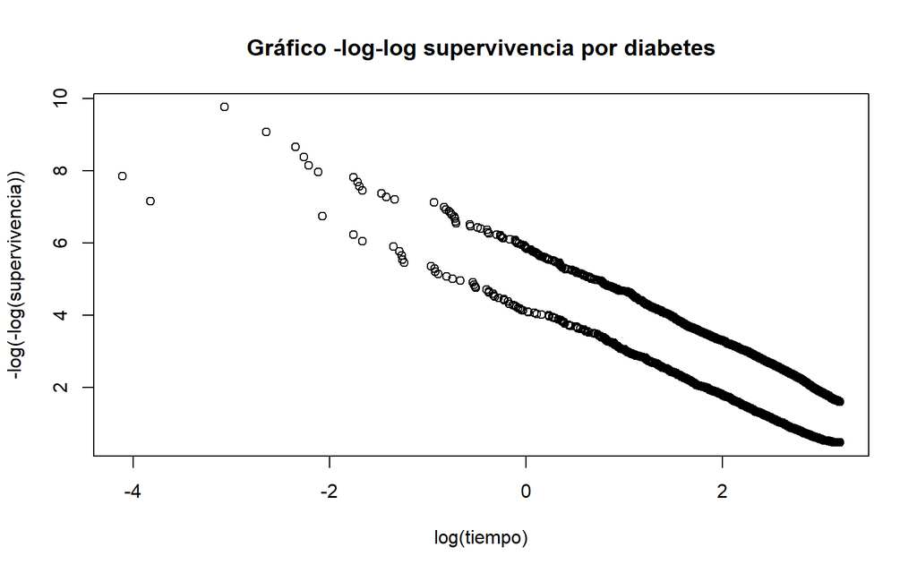

```r
# Crear el gráfico log(-log(supervivencia))
surv_fit_bydm <-
  survfit(Surv(person_years, d000) ~ has_diabetes,
           data = dummy_df)

plot(x = log(surv_fit_bydm$time),
     y = -log(-log(surv_fit_bydm$surv)),
     xlab = "log(tiempo)",
     ylab = "-log(-log(supervivencia))",
     main = "Gráfico -log-log supervivencia por diabetes")
```

Parece que las líneas son paralelas.

También sería útil revisar otros factores, como la edad.

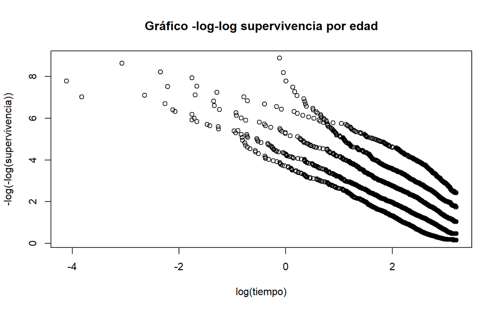

```r
# Crear el gráfico log(-log(supervivencia))
surv_fit_byage <-
  survfit(Surv(person_years, d000) ~ age_10yr,
           data = dummy_df)

plot(x = log(surv_fit_byage$time),
     y = -log(-log(surv_fit_byage$surv)),
     xlab = "log(tiempo)",
     ylab = "-log(-log(supervivencia))",
     main = "Gráfico -log-log supervivencia por edad")
```

Aunque esta es una evaluación relativamente subjetiva, sería razonable decir que no todas las líneas son paralelas. Las dos superiores se cruzan entre sí.

## Prueba formal

La función `cox.zph()` del paquete `survival` correlaciona el conjunto correspondiente de residuales de Schoenfeld escalados con el tiempo (para cada covariable), para probar la independencia entre residuales y tiempo.

Implementado al modelo usado antes:

```r
cox.zph(cox_mod_2)
```

```
##                 chisq df       p
## has_diabetes   46.966  1 7.2e-12
## age_10yr      118.768  4 < 2e-16
## sex             0.453  1  0.5008
## coyoacan        4.756  1  0.0292
## edu_level_cat  33.082  3 3.1e-07
## smokegp_cat    14.983  4  0.0047
## alcgp_cat      40.025  4 4.3e-08
## physgp_cat      9.207  2  0.0100
## GLOBAL        199.268 20 < 2e-16
```

Sugiere que hay razón para creer que el supuesto de RRPP podría no cumplirse, especialmente con respecto a la edad.

**Recuerda**: si la proporcionalidad de riesgos no se cumple, las estrategias incluyen agregar un término de interacción con el tiempo al modelo o estratificar por la covariable.

**Conocimiento avanzado**: Cuando la suposición de proporcionalidad no se cumple, una posibilidad es que el log(HR) varíe en diferentes puntos durante el seguimiento. Por ejemplo, el HR puede ser de ~4 en los primeros 5 años de seguimiento y luego ser de ~2 durante el resto del seguimiento disponible.

Sin embargo, incluso si ese es el caso, el log(HR) general o total aún es una métrica útil que representa el riesgo *promedio* observado durante el seguimiento.

# Resumen

**Este es el final de esta libreta de ejercicios prácticos.**

Durante este práctica:

- Preparaste tus datos y realizaste modelos de Riesgos Proporcionales de Cox para estimar el riesgo de muerte asociado con diabetes.
- Aprendiste algunos enfoques básicos para evaluar las suposiciones de proporcionalidad de modelos Cox PH.

Después de la siguiente sesión teórica, en la siguiente práctica aprenderás cómo implementar modelos de **edad-en-riesgo**.

Regresar a la Tabla de Contenido.